# ex-7-lena-fiedor

Author

Lena Fiedor

### Let’s recall the original plot

I’ll try to repair the horrifying plot prepared by the Polish Ministry of Science and Higher Education. It shows the expenditures declared by entrepreneurs on R&D within the Scientific Research and Development Center between 2010 and 2016.

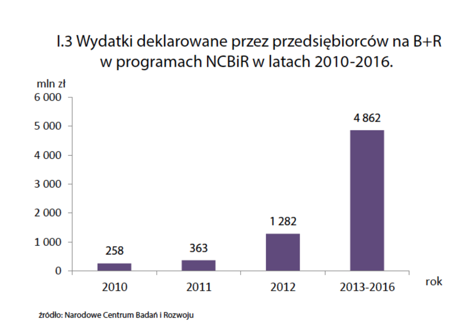

Considering the last bar, the huge increase in spending is actually an aggregate forecast of spendings for the next four years (report was published in 2013). If we would want to divide this sum by four, we obtain mere 1215,5 M zloty for year, that is a decrease of about 5% compared to 2012.

### Restore input data

```r
years <- seq(2010, 2013)
expenditures <- c(258, 363, 1282, 4862/4)
```

### Create a DataFrame

After creating a DataFrame I added a column `isPrediction`, which stores an information if the value of expenditures for a certain year is a forecast or not.

```r
df <- data.frame(Year=years, Expenditures=expenditures)
df$isPrediction=ifelse(df$Year==2013, TRUE, FALSE)
```

### Plot glow-up…

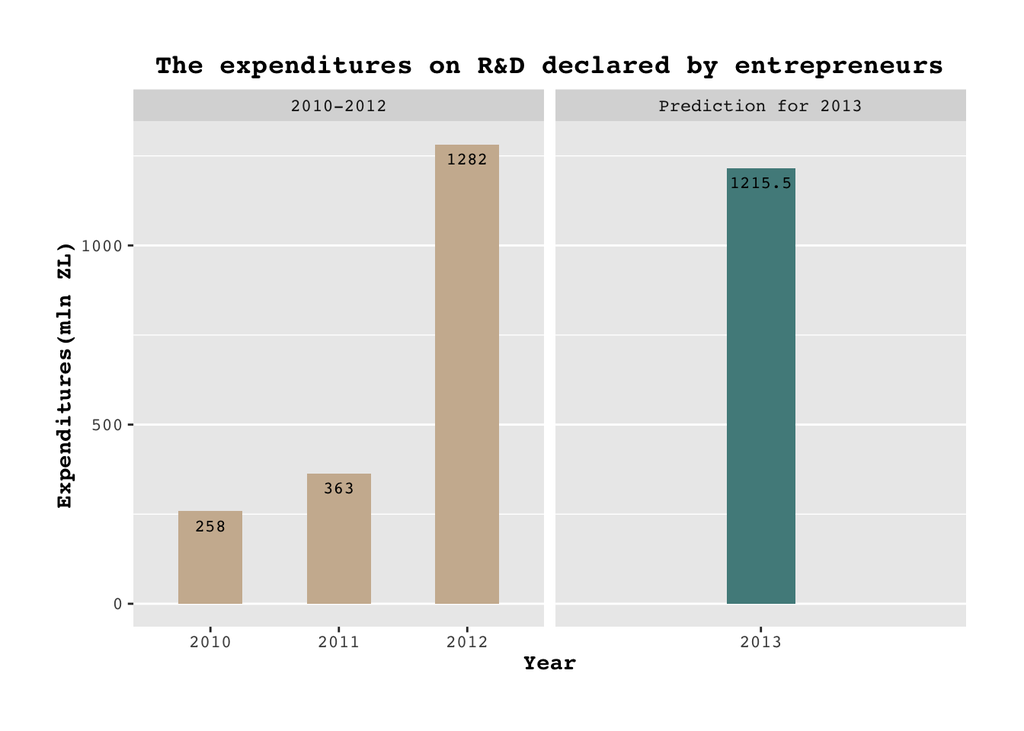

```r
ggplot(df, aes(x=factor(Year), y=Expenditures)) +
  geom_bar(stat='identity', fill=ifelse(df$isPrediction, 'darkslategray4', 'bisque3'), width=ifelse(df$isPrediction, 0.2, 0.5)) + # add bars with colors depending on whether the value is a prediction or not
  geom_text(aes(label=Expenditures, y=Expenditures+1, vjust=2), family='mono', size=3) + # add exact values of the expenditures
  labs( # add labels
    title='The expenditures on R&D declared by entrepreneurs',
    x='Year',
    y='Expenditures(mln ZL)'
  ) +
  theme(
    text=element_text(family='mono'), # set font to monospace
    plot.title=element_text(face='bold', hjust=0.5), # center and bold the title
    axis.title=element_text(face='bold'), # bold the axes titles
    panel.grid.major.x = element_blank(), # remove vertical lines
    plot.margin = unit(rep(10, 4), 'mm') # add margins
  ) +
  facet_wrap(~ifelse(df$isPrediction, 'Prediction for 2013', '2010-2012'), scales='free_x') # split the plot into two separate ones for solid values and predictions
```

### …And save it to file

```r
ggsave(filename='images/pretty_plot.png', height=10, width=15)
```